# Modeling and analysis of WLE dataset

Anantha R. Chadalavada

Sunday, June 21, 2015

### Executive Summary

This report is produced as part of Practical Machine Learning course (Data Science Specialization), offered by Coursera.org. I analyze and build predictive models of Weight Lifting Exercise dataset provided by http://groupware.les.inf.puc-rio.br/har. The dataset contains measurements of weight lifting activity performed. The goal of this project is to predict the manner in which they did exercise, as rerpesented by the variable “classe”.

### Getting and Cleaning Data

- The CSV file was read using read.csv, and it had 19622 observations and 160 features. Summary of features have shown many “NA” values and strings #DIV/0!, which you typically see in Excel spreadsheets. The data was again read by specifying na.strings. (See Figure 1)
- The resulting data frame had more than 100 columns with 19000 or more NA values. These columns were dropped from the dataset.
- The dropped columns are,

** *kurtosis_roll_belt through var_yaw_belt*

** *var_accel_arm through var_yaw_arm*

** *kurtosis_roll_arm through amplitude_yaw_arm*

** *kurtosis_roll_dumbell through var_yaw_dumbell*

** *kurtosis_roll_forearm through var_yaw_forearm*

### Model selection

Since this is a classification problem, I have chosen to compare Random Forest (See Figure 5), GBM (See Figure 6), and Linear Discriminant Analysis (See Figure 7) with cross validation performed by caret package. In each of the model parameters, I have chosen to set traincontrol values.

I would expect the out of sample accuracy to be lower than obtained using RF on the training set.

### Conclusions

In conclusion, modeling with LDA performed worse than RF and GBM (See Figure 8). Although, accuracy of RF and GBM are close, consistently RF produced higher accuracy and kappa statistic than GBM. Similar higher accuracy for RF compared to GBM is also noticed on the out-of-sample “validation”" dataset, that was set aside in the beginning.

## Appendix

```r
library(randomForest)
library(gbm)
library(MASS)
library(e1071)
library(caret)
library(ggplot2)
library(doParallel)
```

**Figure 1**:

```r
cl <- makeCluster(detectCores())
registerDoParallel(cl)

setwd("c:/users/anchad/Documents")
data <- read.csv("pml-training.csv", na.strings=c("NA", "#DIV/0!"))
set.seed(1231)
```

**Figure 2**:

```r
# create training, testing, and validation datasets
# training = 15%, testing = 15%, and validation = 70%

inTrain <- createDataPartition(data$classe, p=0.30, list=FALSE)
trainandtest <- data[inTrain,]
validation <- data[-inTrain,]
dim(trainandtest)
```

```
## [1] 5889  160
```

```r
inTrain <- createDataPartition(trainandtest$classe, p=0.50, list=FALSE)
training <- trainandtest[inTrain,]
testing <- trainandtest[-inTrain,]
dim(training)
```

```
## [1] 2946  160
```

```r
dim(testing)
```

```
## [1] 2943  160
```

**Figure 3**:

```r
# Data cleaning
# Remove columns containing NA
training <- training[,-(12:36)]
training <- training[,-(25:34)]
training <- training[,-(34:48)]
training <- training[,-(37:62)]
training <- training[,-(49:74)]

testing <- testing[,-(12:36)]
testing <- testing[,-(25:34)]
testing <- testing[,-(34:48)]
testing <- testing[,-(37:62)]
testing <- testing[,-(49:74)]

# Remove identifier and date time columns that are not suitable for modeling
training <- training[,-(1:7)]
testing <- testing[,-(1:7)]

dim(training)
```

```
## [1] 2946   51
```

```r
dim(testing)
```

```
## [1] 2943   51
```

**Figure 4**:

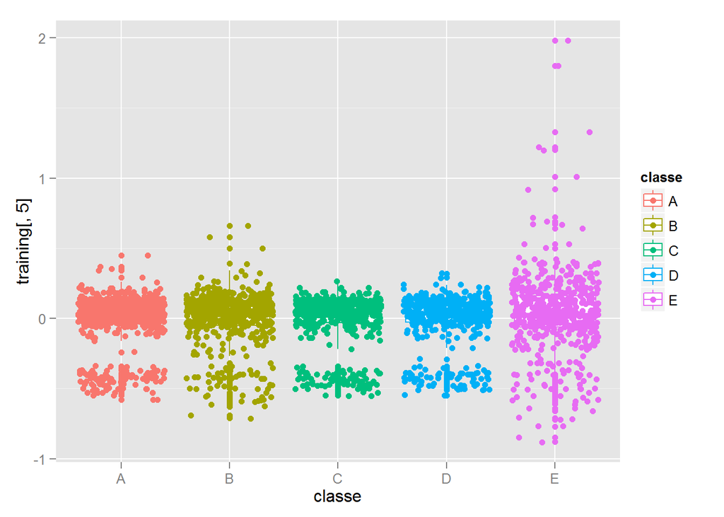

```r
# Example exploratory analysis
qplot(classe, training[,5], data=training, color=classe, geom=c("boxplot", "jitter"))
```

**Figure 5**:

```r
fitControl <- trainControl(method = "cv", number=5)

rfFit <- train(classe ~ ., data = training, method = "rf", trControl = fitControl, verbose = FALSE)
rfFit
```

```
## Random Forest
##
## 2946 samples
##   50 predictor
##    5 classes: 'A', 'B', 'C', 'D', 'E'
##
## No pre-processing
## Resampling: Cross-Validated (5 fold)
##
## Summary of sample sizes: 2356, 2357, 2357, 2356, 2358
##
## Resampling results across tuning parameters:
##
##   mtry  Accuracy   Kappa      Accuracy SD  Kappa SD
##    2    0.9552007  0.9433110  0.009614778  0.01219898
##   26    0.9524738  0.9398439  0.011408559  0.01448441
##   50    0.9361790  0.9192542  0.008585523  0.01089943
##
## Accuracy was used to select the optimal model using  the largest value.
## The final value used for the model was mtry = 2.
```

```r
confusionMatrix(testing$classe, predict(rfFit,testing))
```

```
## Confusion Matrix and Statistics
##
##           Reference
## Prediction   A   B   C   D   E
##          A 827   5   3   0   2
##          B  23 525  22   0   0
##          C   0   8 503   2   0
##          D   0   0  38 442   2
##          E   0   2   2   5 532
##
## Overall Statistics
##
##                Accuracy : 0.9613
##                  95% CI : (0.9536, 0.9679)
##     No Information Rate : 0.2888
##     P-Value [Acc > NIR] : < 2.2e-16
##
##                   Kappa : 0.951
##  Mcnemar's Test P-Value : NA
##
## Statistics by Class:
##
##                      Class: A Class: B Class: C Class: D Class: E
## Sensitivity            0.9729   0.9722   0.8856   0.9844   0.9925
## Specificity            0.9952   0.9813   0.9958   0.9840   0.9963
## Pos Pred Value         0.9881   0.9211   0.9805   0.9170   0.9834
## Neg Pred Value         0.9891   0.9937   0.9733   0.9972   0.9983
## Prevalence             0.2888   0.1835   0.1930   0.1526   0.1821
## Detection Rate         0.2810   0.1784   0.1709   0.1502   0.1808
## Detection Prevalence   0.2844   0.1937   0.1743   0.1638   0.1838
## Balanced Accuracy      0.9841   0.9767   0.9407   0.9842   0.9944
```

**Figure 6**:

```r
gbFit <- train(classe ~ ., data = training, method = "gbm", trControl = fitControl, verbose = FALSE)
gbFit
```

```
## Stochastic Gradient Boosting
##
## 2946 samples
##   50 predictor
##    5 classes: 'A', 'B', 'C', 'D', 'E'
##
## No pre-processing
## Resampling: Cross-Validated (5 fold)
##
## Summary of sample sizes: 2357, 2357, 2356, 2356, 2358
##
## Resampling results across tuning parameters:
##
##   interaction.depth  n.trees  Accuracy   Kappa      Accuracy SD
##   1                   50      0.7413747  0.6721486  0.03511433
##   1                  100      0.8062028  0.7546266  0.02532714
##   1                  150      0.8418421  0.7998524  0.02391652
##   2                   50      0.8343718  0.7904181  0.02210265
##   2                  100      0.8876636  0.8578324  0.01971548
##   2                  150      0.9127754  0.8896628  0.01444028
##   3                   50      0.8808666  0.8492542  0.01188899
##   3                  100      0.9229529  0.9025013  0.01122903
##   3                  150      0.9334833  0.9158205  0.01612730
##   Kappa SD
##   0.04450102
##   0.03199598
##   0.03012430
##   0.02783603
##   0.02491445
##   0.01822003
##   0.01501997
##   0.01418587
##   0.02044582
##
## Tuning parameter 'shrinkage' was held constant at a value of 0.1
##
## Tuning parameter 'n.minobsinnode' was held constant at a value of 10
## Accuracy was used to select the optimal model using  the largest value.
## The final values used for the model were n.trees = 150,
##  interaction.depth = 3, shrinkage = 0.1 and n.minobsinnode = 10.
```

```r
confusionMatrix(testing$classe, predict(gbFit,testing))
```

```
## Confusion Matrix and Statistics
##
##           Reference
## Prediction   A   B   C   D   E
##          A 813  15   5   1   3
##          B  22 519  19   6   4
##          C   0  11 492  10   0
##          D   0   6  29 445   2
##          E   3  10   5  11 512
##
## Overall Statistics
##
##                Accuracy : 0.945
##                  95% CI : (0.9361, 0.9529)
##     No Information Rate : 0.2847
##     P-Value [Acc > NIR] : < 2.2e-16
##
##                   Kappa : 0.9304
##  Mcnemar's Test P-Value : 0.0003283
##
## Statistics by Class:
##
##                      Class: A Class: B Class: C Class: D Class: E
## Sensitivity            0.9702   0.9251   0.8945   0.9408   0.9827
## Specificity            0.9886   0.9786   0.9912   0.9850   0.9880
## Pos Pred Value         0.9713   0.9105   0.9591   0.9232   0.9464
## Neg Pred Value         0.9881   0.9823   0.9761   0.9886   0.9963
## Prevalence             0.2847   0.1906   0.1869   0.1607   0.1770
## Detection Rate         0.2762   0.1764   0.1672   0.1512   0.1740
## Detection Prevalence   0.2844   0.1937   0.1743   0.1638   0.1838
## Balanced Accuracy      0.9794   0.9519   0.9429   0.9629   0.9854
```

**Figure 7**:

```r
ldFit <- train(classe ~ ., data = training, method = "lda", trControl = trainControl(method="cv"))
ldFit
```

```
## Linear Discriminant Analysis
##
## 2946 samples
##   50 predictor
##    5 classes: 'A', 'B', 'C', 'D', 'E'
##
## No pre-processing
## Resampling: Cross-Validated (10 fold)
##
## Summary of sample sizes: 2650, 2651, 2652, 2651, 2651, 2651, ...
##
## Resampling results
##
##   Accuracy   Kappa      Accuracy SD  Kappa SD
##   0.6836466  0.5996915  0.02129909   0.02618508
##
##
```

```r
confusionMatrix(testing$classe, predict(ldFit,testing))
```

```
## Confusion Matrix and Statistics
##
##           Reference
## Prediction   A   B   C   D   E
##          A 667  26  71  67   6
##          B  94 348  76  23  29
##          C  61  38 346  61   7
##          D  24  24  57 355  22
##          E  30  98  49  67 297
##
## Overall Statistics
##
##                Accuracy : 0.684
##                  95% CI : (0.6669, 0.7008)
##     No Information Rate : 0.2977
##     P-Value [Acc > NIR] : < 2.2e-16
##
##                   Kappa : 0.6001
##  Mcnemar's Test P-Value : < 2.2e-16
##
## Statistics by Class:
##
##                      Class: A Class: B Class: C Class: D Class: E
## Sensitivity            0.7614   0.6517   0.5776   0.6195   0.8227
## Specificity            0.9178   0.9078   0.9288   0.9464   0.9055
## Pos Pred Value         0.7969   0.6105   0.6745   0.7365   0.5490
## Neg Pred Value         0.9008   0.9216   0.8959   0.9114   0.9734
## Prevalence             0.2977   0.1814   0.2035   0.1947   0.1227
## Detection Rate         0.2266   0.1182   0.1176   0.1206   0.1009
## Detection Prevalence   0.2844   0.1937   0.1743   0.1638   0.1838
## Balanced Accuracy      0.8396   0.7798   0.7532   0.7830   0.8641
```

**Figure 8**:

```r
# Out of sample error with Validation dataset
validation <- validation[,-(12:36)]
validation <- validation[,-(25:34)]
validation <- validation[,-(34:48)]
validation <- validation[,-(37:62)]
validation <- validation[,-(49:74)]
validation <- validation[,-(1:7)]

# OOS error for RF
confusionMatrix(validation$classe, predict(rfFit,validation))
```

```
## Confusion Matrix and Statistics
##
##           Reference
## Prediction    A    B    C    D    E
##          A 3877   11    6    7    5
##          B   94 2447  115    1    0
##          C    2   63 2310   20    0
##          D    2    0  151 2087   11
##          E    1    8   16   23 2476
##
## Overall Statistics
##
##                Accuracy : 0.961
##                  95% CI : (0.9576, 0.9641)
##     No Information Rate : 0.2895
##     P-Value [Acc > NIR] : < 2.2e-16
##
##                   Kappa : 0.9506
##  Mcnemar's Test P-Value : < 2.2e-16
##
## Statistics by Class:
##
##                      Class: A Class: B Class: C Class: D Class: E
## Sensitivity            0.9751   0.9676   0.8891   0.9761   0.9936
## Specificity            0.9970   0.9813   0.9924   0.9859   0.9957
## Pos Pred Value         0.9926   0.9210   0.9645   0.9271   0.9810
## Neg Pred Value         0.9899   0.9926   0.9746   0.9956   0.9986
## Prevalence             0.2895   0.1842   0.1892   0.1557   0.1815
## Detection Rate         0.2823   0.1782   0.1682   0.1520   0.1803
## Detection Prevalence   0.2844   0.1935   0.1744   0.1639   0.1838
## Balanced Accuracy      0.9861   0.9744   0.9408   0.9810   0.9947
```

```r
# OOS error for GBM
confusionMatrix(validation$classe, predict(gbFit,validation))
```

```
## Confusion Matrix and Statistics
##
##           Reference
## Prediction    A    B    C    D    E
##          A 3803   56   15   12   20
##          B   95 2432  110    5   15
##          C    0   74 2264   56    1
##          D    4    6   82 2133   26
##          E   11   52   32   41 2388
##
## Overall Statistics
##
##                Accuracy : 0.9481
##                  95% CI : (0.9442, 0.9517)
##     No Information Rate : 0.2849
##     P-Value [Acc > NIR] : < 2.2e-16
##
##                   Kappa : 0.9343
##  Mcnemar's Test P-Value : 2.568e-16
##
## Statistics by Class:
##
##                      Class: A Class: B Class: C Class: D Class: E
## Sensitivity            0.9719   0.9282   0.9045   0.9493   0.9747
## Specificity            0.9895   0.9798   0.9883   0.9897   0.9879
## Pos Pred Value         0.9736   0.9153   0.9453   0.9476   0.9461
## Neg Pred Value         0.9888   0.9830   0.9789   0.9901   0.9945
## Prevalence             0.2849   0.1908   0.1823   0.1636   0.1784
## Detection Rate         0.2769   0.1771   0.1649   0.1553   0.1739
## Detection Prevalence   0.2844   0.1935   0.1744   0.1639   0.1838
## Balanced Accuracy      0.9807   0.9540   0.9464   0.9695   0.9813
```

```r
# OOS error for LDA
confusionMatrix(validation$classe, predict(ldFit,validation))
```

```
## Confusion Matrix and Statistics
##
##           Reference
## Prediction    A    B    C    D    E
##          A 3185  121  241  328   31
##          B  401 1643  368  149   96
##          C  305  204 1519  321   46
##          D  141   82  246 1673  109
##          E  128  461  244  286 1405
##
## Overall Statistics
##
##                Accuracy : 0.6863
##                  95% CI : (0.6785, 0.6941)
##     No Information Rate : 0.3029
##     P-Value [Acc > NIR] : < 2.2e-16
##
##                   Kappa : 0.6028
##  Mcnemar's Test P-Value : < 2.2e-16
##
## Statistics by Class:
##
##                      Class: A Class: B Class: C Class: D Class: E
## Sensitivity            0.7656   0.6543   0.5802   0.6068   0.8328
## Specificity            0.9247   0.9096   0.9212   0.9473   0.9071
## Pos Pred Value         0.8154   0.6184   0.6342   0.7432   0.5567
## Neg Pred Value         0.9008   0.9216   0.9031   0.9056   0.9748
## Prevalence             0.3029   0.1828   0.1906   0.2008   0.1228
## Detection Rate         0.2319   0.1196   0.1106   0.1218   0.1023
## Detection Prevalence   0.2844   0.1935   0.1744   0.1639   0.1838
## Balanced Accuracy      0.8452   0.7820   0.7507   0.7771   0.8700
```

```r
stopCluster(cl)
```